[figure not shown]

RBC Chair in Cardiovascular Nursing Research | Peter Munk Cardiac Centre  
Assistant Professor | Lawrence S. Bloomberg Faculty of Nursing | University of Toronto

**Aaron Conway BN (Hons) PhD**

aaron.conway@utoronto.ca

# Education

- *PhD*  
  Australian Catholic University  
  Brisbane, AU 2010 - 2012
- *Bachelor of Nursing (Honours)*  
  Australian Catholic University  
  Brisbane, AU 2007 - 2008
- *Bachelor of Nursing*  
  Australian Catholic University  
  Brisbane, AU 2004 - 2006

# Employment

- *RBC Chair in Cardiovasacular Nursing Research*  
  University of Toronto  
  Toronto, CA 2018 - Current
- *Senior Research Fellow*  
  Queensland University of Technology  
  Brisbane, AU 2017 - 2018
- *Registered Nurse*  
  Wesley Hospital  
  Brisbane, AU 2007 - 2018
- *Research Fellow*  
  Queensland University of Technology  
  Brisbane, AU 2013 - 2017

# Awards

- *Top 1% of Reviewers in the field of Clinical Medicine*  
  Publons 2018
- *Top 1% Reviewers in Nursing*  
  Publons 2017
- *Sentinels of Science: Nursing*  
  Publons 2016
- *Mary Hanna Memorial Journalism Award*  
  American Society of PeriAnesthesia Nurses 2015
- *Best Reviewer Award*  
  Research in Nursing and Health 2013
- *Travel Award*  
  Cardiac Society of Australia and New Zealand 2012
- *Runner-up, Novice Researcher Prize*  
  Prince Charles Hospital 2012
- *runner-up, Nursing Affiliate’s Prize*  
  Cardiac Society of Australia and New Zealand 2012
- *Best poster and mini-oral presentation*  
  Australasian Cardiovascular Nursing College 2012
- *Commitment to Safety & Quality Award*  
  Wesley Hospital 2011
- *Travel Bursary*  
  Wesley Hospital 2011
- *Best poster and mini-oral presentation*  
  Australasian Cardiovascular Nursing College 2011

# Service

- *Associate Editor*  
  Systematic Reviews 2019 - Current
- *Grant review panel*  
  National Health and Medical Research Council 2019 - 2019
- *Chair, Conference committee*  
  Australasian Cardiovascular Nursing College 2017 - 2018
- *External peer reviewer*  
  National Health and Medical Research Council 2018 - 2018
- *Secretary*  
  Australasian Cardiovascular Nursing College 2017 - 2018
- *Executive Committee Member*  
  Interventional Nurses Council 2016 - 2018
- *Committee member*  
  Sedation Consortium on Endpoints and Procedures for Treatment, Education, and Research (SCEPTER) 2017 - 2017
- *Conference Committee*  
  Australasian Cardiovascular Nursing College 2016 - 2017

# Memberships

- *Member*  
  Sigma Theta Tau International 2010 - Current
- *Affiliate member*  
  Cardiac Society of Australia and New Zealand 2010 - Current
- *Member*  
  Australasian Cardiovascular Nursing College 2010 - Current
- *Member*  
  Australian College of Nursing 2006 - Current

# Funding

- *Optimising the clinical application of capnography for monitoring of ventilation during sedation in the cardiac catheterisation laboratory*  
  Wesley Medical Research  
  $18356 2016 - 2019
- *Maintaining normoTHERMIa during SEDation: The Thermised Pilot Study*  
  St. Vincent’s Clinic Foundation  
  $25000 2016 - 2016
- *Ascertaining the effectiveness of current nursing practices in maintaining normothermia during procedures performed in the cardiac catheterisation laboratory*  
  Interventional Nurses Council  
  $5000 2014 - 2014
- *A pilot study of nurse-led screening for anxiety and depression in adult heart transplant recipients followed by referral for cognitive behaviour therapy ad co-ordination of communication with ongoing specialist and primary care providers*  
  Sigma Theta Tau International  
  $5604 2014 - 2014
- *Postgraduate scholarship*  
  Queensland Nursing Council  
  $5000 2007 - 2008
- *Australian Postgraduate Award*  
  Australian Catholic University  
  $71664 2011 - 2012
- *High flow nasal oxygen for sedation*  
  Connaught Fund  
  $19000 2019 - 2021
- *Improving nurse-administered sedation practice in the cardiac catheterisation laboratory*  
  National Health and Medical Research Council  
  $309436 2015 - 2019

# Publications

14 h-index

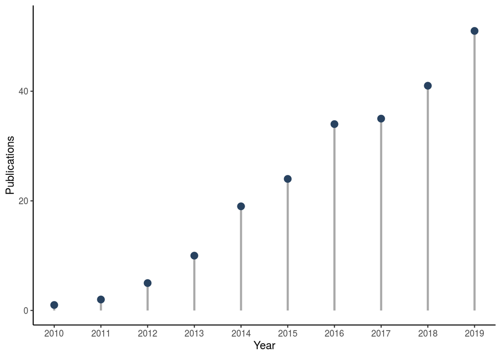

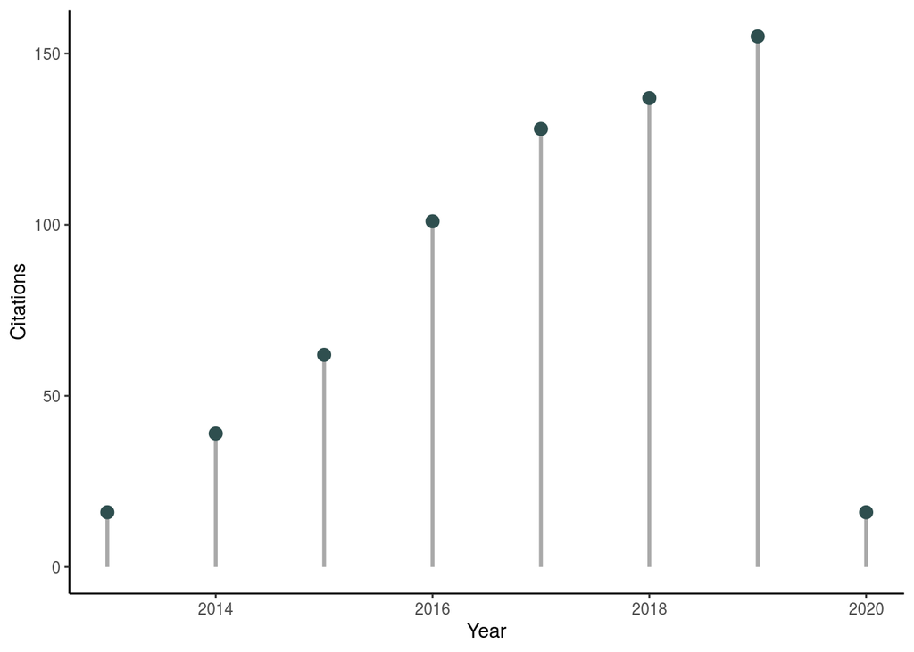

## Journal articles

1. Nicholas Ralph, Jeffrey Gow, Aaron Conway, et al. (2019). Costs of inadvertent perioperative hypothermia in Australia: A cost-of-illness study. *Collegian*. [doi:10.1016/j.colegn.2019.10.003](https://dx.doi.org/10.1016/j.colegn.2019.10.003)
2. Aaron Conway, Peter Collins, Kristina Chang, et al. (2019). Sequence analysis of capnography waveform abnormalities during nurse-administered procedural sedation and analgesia in the cardiac catheterization laboratory. *Scientific Reports*, **9**. [doi:10.1038/s41598-019-46751-2](https://dx.doi.org/10.1038/s41598-019-46751-2)
3. Mary-Anne Ramis, Anne Chang, Aaron Conway, et al. (2019). Theory-based strategies for teaching evidence-based practice to undergraduate health students: a systematic review. *BMC Medical Education*, **19**. [doi:10.1186/s12909-019-1698-4](https://dx.doi.org/10.1186/s12909-019-1698-4)
4. Aaron Conway, Peter Collins, Kristina Chang, et al. (2019). Pre-apneic capnography waveform abnormalities during procedural sedation and analgesia. *Journal of Clinical Monitoring and Computing*. [doi:10.1007/s10877-019-00391-z](https://dx.doi.org/10.1007/s10877-019-00391-z)
5. Aaron Conway, Jeffrey Gow, Nicholas Ralph, et al. (2019). Implementing a thermal care bundle for inadvertent perioperative hypothermia: A cost-effectiveness analysis. *International Journal of Nursing Studies*, **97**, 21-27. [doi:10.1016/j.ijnurstu.2019.04.017](https://dx.doi.org/10.1016/j.ijnurstu.2019.04.017)
6. Amy J. Spooner, Natasha Booth, Tai-Rae Downer, et al. (2019). Advanced practice profiles and work activities of nurse navigators: An early-stage evaluation. *Collegian*, **26**, 103-109. [doi:10.1016/j.colegn.2018.05.003](https://dx.doi.org/10.1016/j.colegn.2018.05.003)
7. Adrienne P. Hudson, Amy J. Spooner, Natasha Booth, et al. (2019). Qualitative insights of patients and carers under the care of nurse navigators. *Collegian*, **26**, 110-117. [doi:10.1016/j.colegn.2018.05.002](https://dx.doi.org/10.1016/j.colegn.2018.05.002)
8. Aaron Conway, Elizabeth Tipton, Wei-Hong Liu, et al. (2018). Accuracy and precision of transcutaneous carbon dioxide monitoring: a systematic review and meta-analysis. *Thorax*, **74**, 157-163. [doi:10.1136/thoraxjnl-2017-211466](https://dx.doi.org/10.1136/thoraxjnl-2017-211466)
9. Aaron Conway, Jed Duff, Joanna Sutherland. (2018). Cost-effectiveness of forced air warming during sedation in the cardiac catheterisation laboratory. *Journal of Advanced Nursing*, **74**, 2075-2081. [doi:10.1111/jan.13707](https://dx.doi.org/10.1111/jan.13707)
10. William Parker, Cameron G. Estrich, Elliot Abt, et al. (2018). Benefits and harms of capnography during procedures involving moderate sedation. *The Journal of the American Dental Association*, **149**, 38-50.e2. [doi:10.1016/j.adaj.2017.08.030](https://dx.doi.org/10.1016/j.adaj.2017.08.030)
11. Denham S. Ward, Mark R. Williams, John W. Berkenbosch, et al. (2018). Evaluating Patient-Centered Outcomes in Clinical Trials of Procedural Sedation, Part 2 Safety. *Anesthesia & Analgesia*, **127**, 1146-1154. [doi:10.1213/ane.0000000000003409](https://dx.doi.org/10.1213/ane.0000000000003409)
12. Aaron Conway. (2018). Nurses should inform patients of the possibility of awareness during bronchoscopy performed with procedural sedation. *Evidence Based Nursing*, **21**, 82-83. [doi:10.1136/eb-2018-102922](https://dx.doi.org/10.1136/eb-2018-102922)
13. Aaron Conway, Zachary Conway, Kathleen Soalheira, et al. (2018). Reply to. *European Journal of Anaesthesiology*, **35**, 637-638. [doi:10.1097/eja.0000000000000851](https://dx.doi.org/10.1097/eja.0000000000000851)
14. Aaron Conway, Suzanna Ersotelos, Joanna Sutherland, et al. (2017). Forced air warming during sedation in the cardiac catheterisation laboratory: a randomised controlled trial. *Heart*, **104**, 685-690. [doi:10.1136/heartjnl-2017-312191](https://dx.doi.org/10.1136/heartjnl-2017-312191)
15. Aaron Conway, Zachary Conway, Kathleen Soalheira, et al. (2017). High quality of evidence is uncommon in Cochrane systematic reviews in Anaesthesia, Critical Care and Emergency Medicine. *European Journal of Anaesthesiology*, **34**, 808-813. [doi:10.1097/eja.0000000000000691](https://dx.doi.org/10.1097/eja.0000000000000691)
16. Aaron Conway, Judith Sheridan, Joanne Maddicks-Law, et al. (2016). Depression and Pain in Heart Transplant Recipients. *Biological Research For Nursing*, **19**, 71-76. [doi:10.1177/1099800416666717](https://dx.doi.org/10.1177/1099800416666717)
17. Aaron Conway, Judith Sheridan, Joanne Maddicks-Law, et al. (2016). Pilot testing a model of psychological care for heart transplant recipients. *BMC Nursing*, **15**. [doi:10.1186/s12912-016-0183-1](https://dx.doi.org/10.1186/s12912-016-0183-1)
18. Aaron Conway, Judith Sheridan, Joanne Maddicks-Law, et al. (2016). Accuracy of anxiety and depression screening tools in heart transplant recipients. *Applied Nursing Research*, **32**, 177-181. [doi:10.1016/j.apnr.2016.07.015](https://dx.doi.org/10.1016/j.apnr.2016.07.015)
19. Aaron Conway. (2016). A Review of the Effects of Sedation on Thermoregulation: Insights for the Cardiac Catheterization Laboratory. *Journal of PeriAnesthesia Nursing*, **31**, 226-236. [doi:10.1016/j.jopan.2014.07.016](https://dx.doi.org/10.1016/j.jopan.2014.07.016)
20. A. Conway, C. Douglas, J. R. Sutherland. (2016). A systematic review of capnography for sedation. *Anaesthesia*, **71**, 450-454. [doi:10.1111/anae.13378](https://dx.doi.org/10.1111/anae.13378)
21. Aaron Conway, Clint Douglas, Joanna R Sutherland. (2016). Capnography for Moderate Sedation During Routine EGD and Colonoscopy. *American Journal of Gastroenterology*, **111**, 1208. [doi:10.1038/ajg.2016.161](https://dx.doi.org/10.1038/ajg.2016.161)
22. Aaron Conway, Joanna Sutherland. (2016). Depth of anaesthesia monitoring during procedural sedation and analgesia: A systematic review and meta-analysis. *International Journal of Nursing Studies*, **63**, 201-212. [doi:10.1016/j.ijnurstu.2016.05.004](https://dx.doi.org/10.1016/j.ijnurstu.2016.05.004)
23. Aaron Conway, Jed Duff. (2016). Forced air warming to maintain normoTHERMIa during SEDation in the cardiac catheterization laboratory: protocol for the THERMISED pilot randomized controlled trial. *Journal of Advanced Nursing*, **72**, 2547-2557. [doi:10.1111/jan.13027](https://dx.doi.org/10.1111/jan.13027)
24. Aaron Conway, John Rolley, Joanna R Sutherland. (2016). Midazolam for sedation before procedures. *Cochrane Database of Systematic Reviews*. [doi:10.1002/14651858.cd009491.pub2](https://dx.doi.org/10.1002/14651858.cd009491.pub2)
25. Wendy Kennedy, Aaron Conway. (2016). Temperature monitoring of nonanaesthetised patients in a cardiac catheterisation laboratory. *Journal of Clinical Nursing*, **25**, 1777-1780. [doi:10.1111/jocn.13213](https://dx.doi.org/10.1111/jocn.13213)
26. Aaron Conway, Wendy Kennedy, Joanna Sutherland. (2015). Inadvertent Hypothermia After Procedural Sedation and Analgesia in a Cardiac Catheterization Laboratory: A Prospective Observational Study. *Journal of Cardiothoracic and Vascular Anesthesia*, **29**, 1285-1290. [doi:10.1053/j.jvca.2015.06.002](https://dx.doi.org/10.1053/j.jvca.2015.06.002)
27. Aaron Conway, Clint Douglas, Joanna Sutherland. (2015). Capnography monitoring during procedural sedation and analgesia: a systematic review protocol. *Systematic Reviews*, **4**. [doi:10.1186/s13643-015-0085-4](https://dx.doi.org/10.1186/s13643-015-0085-4)
28. Aaron Conway, Joanna Sutherland. (2015). Depth of anaesthesia monitoring during procedural sedation and analgesia: a systematic review protocol. *Systematic Reviews*, **4**. [doi:10.1186/s13643-015-0061-z](https://dx.doi.org/10.1186/s13643-015-0061-z)
29. Aaron Conway, Alexandra L McCarthy, Petra Lawrence, et al. (2015). The prevention, detection and management of cancer treatment-induced cardiotoxicity: a meta-review. *BMC Cancer*, **15**. [doi:10.1186/s12885-015-1407-6](https://dx.doi.org/10.1186/s12885-015-1407-6)
30. Sally C Inglis, Aaron Conway, John GF Cleland, et al. (2014). Is age a factor in the success or failure of remote monitoring in heart failure? Telemonitoring and structured telephone support in elderly heart failure patients. *European Journal of Cardiovascular Nursing*, **14**, 248-255. [doi:10.1177/1474515114530611](https://dx.doi.org/10.1177/1474515114530611)
31. Aaron Conway, Karen Page, John X. Rolley, et al. (2014). A Review of Sedation Scales for the Cardiac Catheterization Laboratory. *Journal of PeriAnesthesia Nursing*, **29**, 191-212. [doi:10.1016/j.jopan.2013.05.017](https://dx.doi.org/10.1016/j.jopan.2013.05.017)
32. Aaron Conway. (2014). Anaesthesiological support in a cardiac electrophysiology laboratory. *European Journal of Anaesthesiology*, **31**, 237-238. [doi:10.1097/eja.0000000000000032](https://dx.doi.org/10.1097/eja.0000000000000032)
33. Aaron Conway, Sally C. Inglis, Robyn A. Clark. (2014). Effective Technologies for Noninvasive Remote Monitoring in Heart Failure. *Telemedicine and e-Health*, **20**, 531-538. [doi:10.1089/tmj.2013.0267](https://dx.doi.org/10.1089/tmj.2013.0267)
34. A. Conway. (2014). Is sedation by non-anaesthetists really safe?. *British Journal of Anaesthesia*, **112**, 583-584. [doi:10.1093/bja/aeu033](https://dx.doi.org/10.1093/bja/aeu033)
35. Aaron Conway, Verena Schadewaldt, Robyn Clark, et al. (2014). The effectiveness of non-pharmacological interventions in improving psychological outcomes for heart transplant recipients: A systematic review. *European Journal of Cardiovascular Nursing*, **13**, 108-115. [doi:10.1177/1474515113519519](https://dx.doi.org/10.1177/1474515113519519)
36. Aaron Conway, John Rolley, Karen Page, et al. (2014). Trends in nurse-administered procedural sedation and analgesia across cardiac catheterisation laboratories in Australia and New Zealand: Results of an electronic survey. *Australian Critical Care*, **27**, 4-10. [doi:10.1016/j.aucc.2013.05.003](https://dx.doi.org/10.1016/j.aucc.2013.05.003)
37. Robyn A Clark, Aaron Conway, Vanessa Poulsen, et al. (2013). Alternative models of cardiac rehabilitation: A systematic review. *European Journal of Preventive Cardiology*, **22**, 35-74. [doi:10.1177/2047487313501093](https://dx.doi.org/10.1177/2047487313501093)
38. Aaron Conway. (2013). Anxiety Score as a Risk Factor for Radial Artery Vasospasm During Radial Interventions. *Angiology*, **65**, 71-72. [doi:10.1177/0003319713505896](https://dx.doi.org/10.1177/0003319713505896)
39. Aaron Conway, John Rolley, Karen Page, et al. (2013). Issues and challenges associated with nurse-administered procedural sedation and analgesia in the cardiac catheterisation laboratory: a qualitative study. *Journal of Clinical Nursing*, **23**, 374-384. [doi:10.1111/jocn.12147](https://dx.doi.org/10.1111/jocn.12147)
40. Aaron Conway, John Rolley, Karen Page, et al. (2013). Clinical practice guidelines for nurse-administered procedural sedation and analgesia in the cardiac catheterization laboratory: a modified Delphi study. *Journal of Advanced Nursing*, **70**, 1040-1053. [doi:10.1111/jan.12337](https://dx.doi.org/10.1111/jan.12337)
41. Aaron Conway, John X. Rolley, Paul Fulbrook, et al. (2013). Improving statistical analysis of matched case-control studies. *Research in Nursing & Health*, **36**, 320-324. [doi:10.1002/nur.21536](https://dx.doi.org/10.1002/nur.21536)
42. Aaron Conway, Sally C Inglis, Anne M Chang, et al. (2013). Not all systematic reviews are systematic: a meta-review of the quality of systematic reviews for non-invasive remote monitoring in heart failure. *Journal of Telemedicine and Telecare*, **19**, 326-337. [doi:10.1177/1357633x13503427](https://dx.doi.org/10.1177/1357633x13503427)
43. Aaron Conway, Verena Schadewaldt, Robyn Clark, et al. (2013). The psychological experiences of adult heart transplant recipients: A systematic review and meta-summary of qualitative findings. *Heart & Lung*, **42**, 449-455. [doi:10.1016/j.hrtlng.2013.08.003](https://dx.doi.org/10.1016/j.hrtlng.2013.08.003)
44. Aaron Conway. (2013). Utility of Dexmedetomidine in Sedation for Radiofrequency Ablation of Atrial Fibrillation. *Journal of PeriAnesthesia Nursing*, **28**, 257-258. [doi:10.1016/j.jopan.2013.07.006](https://dx.doi.org/10.1016/j.jopan.2013.07.006)
45. Aaron Conway, Karen Page, John Rolley, et al. (2012). Risk factors for impaired respiratory function during nurse-administered procedural sedation and analgesia in the cardiac catheterisation laboratory: a matched case–control study. *European Journal of Cardiovascular Nursing*, **12**, 393-399. [doi:10.1177/1474515112470351](https://dx.doi.org/10.1177/1474515112470351)
46. Aaron Conway, Karen Page, John X. Rolley, et al. (2011). Nurse-administered procedural sedation and analgesia in the cardiac catheter laboratory: An integrative review. *International Journal of Nursing Studies*, **48**, 1012-1023. [doi:10.1016/j.ijnurstu.2011.04.013](https://dx.doi.org/10.1016/j.ijnurstu.2011.04.013)

# Open Source Software

- [*spiritR*](https://spiritr.netlify.com)  
  A workflow to enable direct upload of a clinical trial protocol to clinicaltrials.gov 2019

# Peer reviews

> Dr Conway has performed 212 reviews since he commenced an acadmic career in 2013. He is also an Associate Editor for the journal Systematic Reviews.

Created by [Aaron Conway](https://www.aaronconway.info)

*Updated on Sat Feb 08 01:44:20 PM 2020*